# Using Hash to speed up search

### Author: Kevin Shahnazari

### Last updated March 6th 2021

## Introduction

Have you ever thought if you had a list of size N, how long would it take you to check if an element is present in the list or not? Probably you have, and the approach to do this is pretty simple and straightforward as well. You take the list and check the elements one by one, and if we find the element, we would simply return the index of it. This approach would probably work for most applications with small amounts of data, but what if our data was massive?

Consider a list of size 10. The worst-case scenario would be checking the whole list and not finding the element inside. Now let's consider different list sizes such as 100,1000, etc. The number of operations needed to check the existence of an element inside the list is proportional to the length; therefore, this search would be of $O(N)$.

Although this might not sound like a problem, many applications store a vast amount of data that users need to access many times in a short period of time. Take Amazon as an example. Their data consists of millions of rows of data. Each search might take over a few seconds which would be an eternity for each user, not to mention the considerable pressure the Amazon servers have to undergo for every single search!

Thankfully, there is a solution for this in computer science called hash tables, which could address this problem and speed up the search.

## How does it work?

Let's illustrate the algorithms with an example. We have numbers 1,15,28, and 64. Before we start searching for an element, let's specify five different buckets with numbers written 0 to 4 written on them. We would each divide each number by five and calculate the remainder of the operation and put those numbers inside the bucket, which has the remainder of the calculation written on them. The numbers placed in the bucket is shown below:

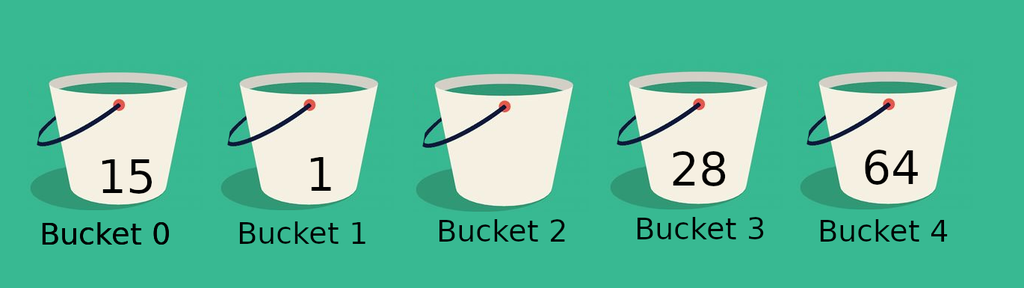

As you can see, not all the buckets are filled in with numbers. If we want to search for a number, we could calculate that number's remainder when divided by 5 and only check inside that bucket. Basically, it would become $O(1)$, because we only check one bucket. The function that we use to map each element to an index within our bucket length is called a hash function which in the previous example was the remainder of dividing the number by 5. Now not every element is a number, so a simple hash function like taking the remainder doesn't work in every scenario. There are more complex hashing methods that could be used to hash strings and floats as well. Specifying lots of buckets means occupying some extra space in memory. Still, with the advancement of technology, we have access to larger memories, and this is not the primary concern anymore, so we are exchanging some of our memory for more speed.

## Scaling the algorithm

Now you might be thinking about what happens if we add a couple of thousands of elements to the list in the previous example. Having only five buckets might not be that useful because we need to search through many elements inside each bucket. Usually, these algorithms adapt themselves to the lists' length and automatically add buckets and reassign the elements so the big O would remain $O(1)$.

## See searching with Hash in action

Let's try to implement the algorithm and see it's speed in action. We would visualize the time taken to do a linear search through the list vs using hashing to search the list. First, let's see the code that calculates the time for the linear search.

```python
import time
import matplotlib.pyplot as plt
from numpy import random
list_sizes = [1,1000,10e4,10e5,10e6]

linear_times = []
for list_size in list_sizes:
    test_list = random.randint(100, size=(int(list_size)))
    start = time.time()
    if -1 in test_list:
        pass
    else:
        pass
    finish = time.time()
    linear_times.append(finish - start)
```

Now let's see the code for searching with hash:

```python
hash_times = []
for list_size in list_sizes:
    hash_table = []
    for num in range(int(10e7)):
        hash_table.append([])
    for num in range(int(list_size)):
        hash_table[hash(num) % int(10e7)].append(num)
    start = time.time()
    index = hash(-1) % int(10e7)
    if -1 in hash_table[index]:
        pass
    else:
        pass
    finish = time.time()
    hash_times.append(finish - start)
```

Now that we have the results, we would plot them on one chart:

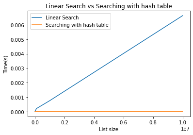

```python
plt.plot(list_sizes,linear_times, label = 'Linear Search');
plt.plot(list_sizes,hash_times, label = "Searching with hash table");
plt.xlabel('List size')
plt.ylabel('Time(s)')
plt.title('Linear Search vs Searching with hash table')
plt.legend();
```

## Results:

As you saw from the plot, the linear search's time complexity increases linearly based on the list size, but by using a hash table, the time complexity does not change. Based on the plot, we can clarify that the time-complexity of linear search is $O(N)$, and for searches with hash tables, it is $O(1)$.

From my personal experience, I would not bother to use a hash table when the list's size is relatively small because it is not worth the headache. But if the length of my list starts growing to a relatively large number and I need to do many searches through the list, using hash tables is the first data structure I would consider.